# Coding Assignment 1

Team 3

Due: 2021-09-29 23:59

```r
# Put any packages you want here
library(readxl)
library(dplyr)
```

```r
library(gt)
library(gtsummary)
library(corrplot)
library(car)
library(jtools)
```

A Florida health insurance company wants to predict annual claims for individual clients. The company pulls a random sample of 50 customers. The owner wishes to charge an actuarially fair premium to ensure a normal rate of return. The owner collects all of their current customer’s health care expenses from the last year and compares them with what is known about each customer’s plan.

The data on the 50 customers in the sample is as follows:

- Charges: Total medical expenses for a particular insurance plan (in dollars)
- Age: Age of the primary beneficiary
- BMI: Primary beneficiary’s body mass index (kg/m2)
- Female: Primary beneficiary’s birth sex (0 = Male, 1 = Female)
- Children: Number of children covered by health insurance plan (includes other dependents as well)
- Smoker: Indicator if primary beneficiary is a smoker (0 = non-smoker, 1 = smoker)
- Cities: Dummy variables for each city with the default being Sanford

Answer the following questions using complete sentences and attach all output, plots, etc. within this report.

**For this assignment, ignore the categorical variables (gender, smoker, cities)**

```r
summary(insurance)
```

```
##     Charges           Age             BMI           Children
##  Min.   : 1242   Min.   :18.00   Min.   :17.80   Min.   :0.00
##  1st Qu.: 4048   1st Qu.:27.00   1st Qu.:29.65   1st Qu.:0.00
##  Median : 9629   Median :45.00   Median :32.31   Median :0.00
##  Mean   :12894   Mean   :41.42   Mean   :32.31   Mean   :0.86
##  3rd Qu.:14188   3rd Qu.:56.00   3rd Qu.:35.97   3rd Qu.:2.00
##  Max.   :55135   Max.   :64.00   Max.   :44.74   Max.   :3.00
```

```r
sd(insurance$Age)
```

```
## [1] 15.53546
```

```r
sd(insurance$BMI)
```

```
## [1] 5.561717
```

```r
sd(insurance$Children)
```

```
## [1] 1.12504
```

# Question 1

Perform univariate analyses on the quantitative variables (center, shape, spread). Include descriptive statistics, and histograms. Be sure to use terms discussed in class such as bimodal, skewed left, etc.

```r
mean(insurance$Age)
```

```
## [1] 41.42
```

```r
median(insurance$Age)
```

```
## [1] 45
```

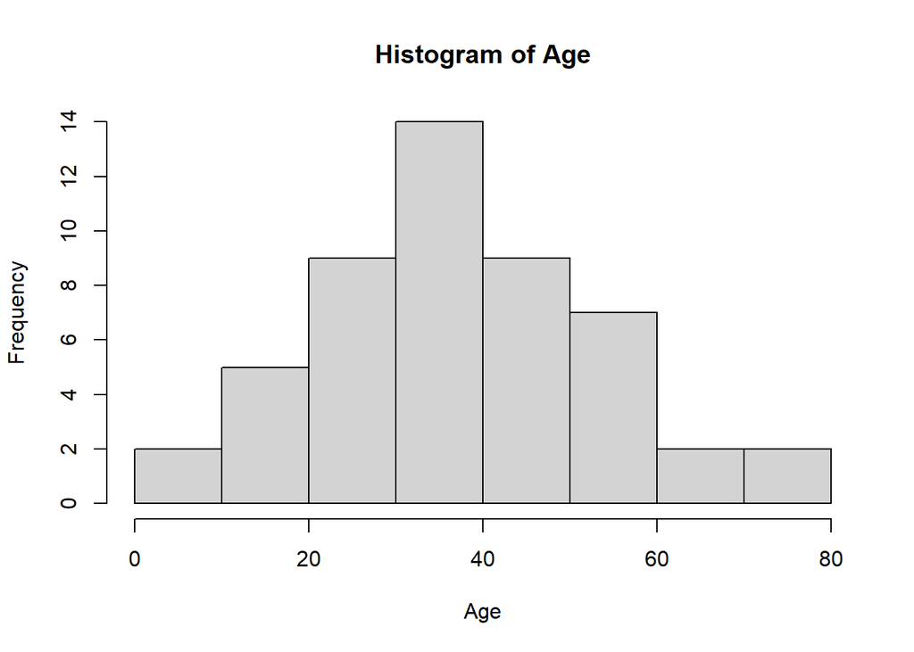

```r
Age <- rnorm(50, mean = 41, sd = 16)
hist(Age)
```

```r
var(Age, na.rm = TRUE)
```

```
## [1] 253.1603
```

```r
sd(Age, na.rm = TRUE)
```

```
## [1] 15.91101
```

```r
IQR(Age, na.rm = TRUE)
```

```
## [1] 20.75815
```

```r
range(Age, na.rm = TRUE)
```

```
## [1]  5.21937 78.93301
```

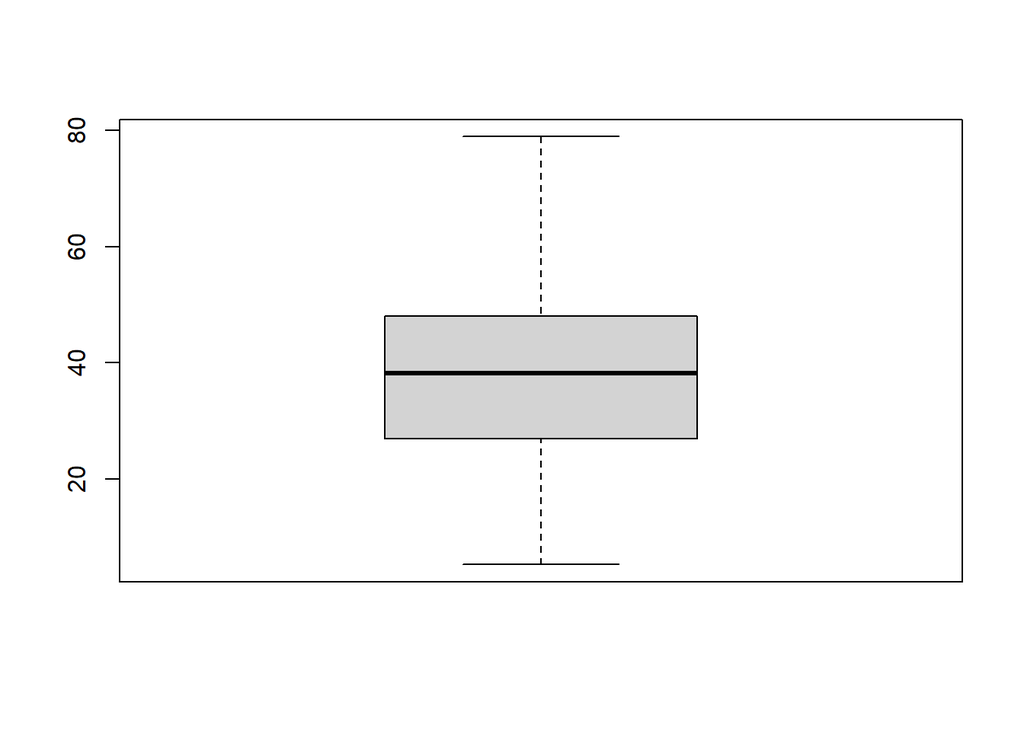

```r
boxplot(Age)
```

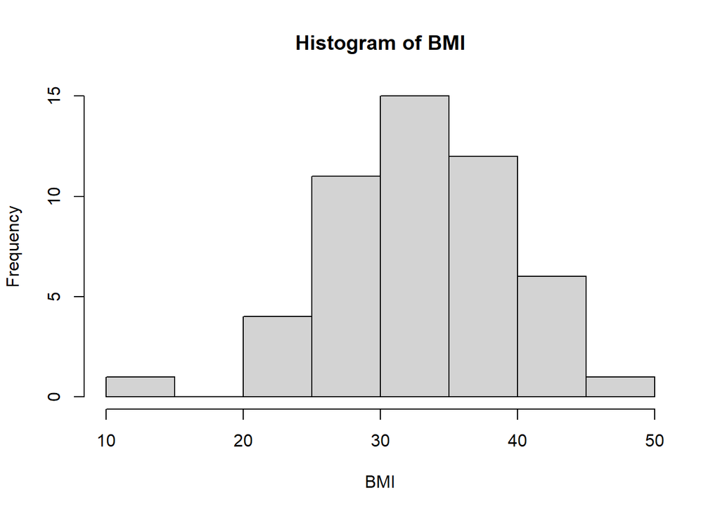

```r
BMI <- rnorm(50, mean = 32.3, sd = 5.6)
hist(BMI)
```

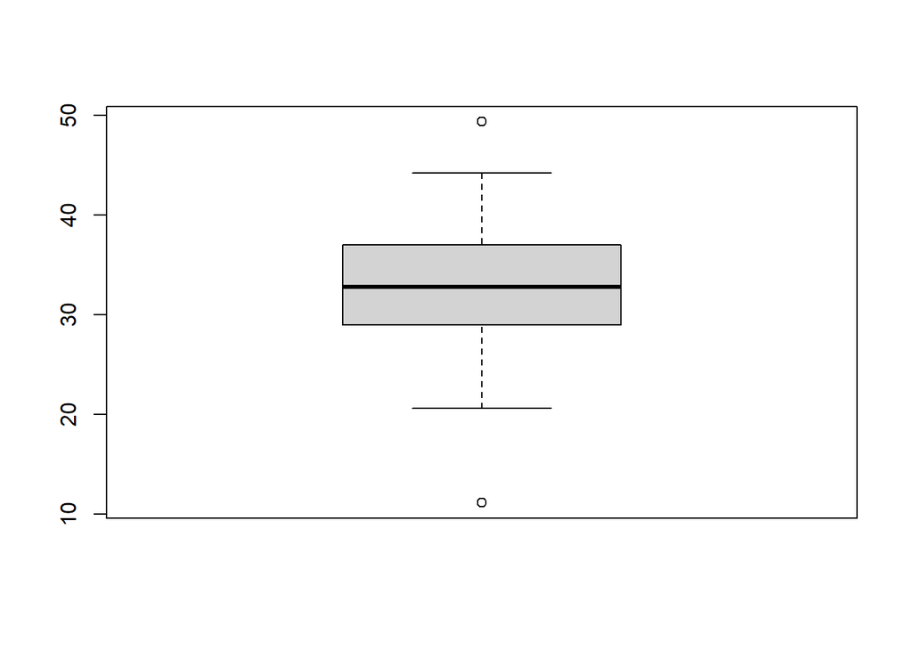

```r
boxplot(BMI)
```

```r
str(insurance)
```

```
## 'data.frame':    50 obs. of  4 variables:
##  $ Charges : num  2457 55135 8522 16085 8557 ...
##  $ Age     : int  20 33 43 64 47 57 31 40 27 53 ...
##  $ BMI     : num  28.8 35.5 34.4 39 36 ...
##  $ Children: int  0 0 3 3 1 0 0 2 0 3 ...
```

```r
head(insurance)
```

```
##     Charges Age    BMI Children
## 1  2457.211  20 28.785        0
## 2 55135.402  33 35.530        0
## 3  8522.003  43 34.400        3
## 4 16085.128  64 39.050        3
## 5  8556.907  47 36.000        1
## 6 27533.913  57 29.810        0
```

```r
tail (insurance, 2)
```

```
##     Charges Age    BMI Children
## 49 12265.51  56 37.510        2
## 50 19442.35  29 33.345        2
```

```r
summary(insurance)
```

```
##     Charges           Age             BMI           Children
##  Min.   : 1242   Min.   :18.00   Min.   :17.80   Min.   :0.00
##  1st Qu.: 4048   1st Qu.:27.00   1st Qu.:29.65   1st Qu.:0.00
##  Median : 9629   Median :45.00   Median :32.31   Median :0.00
##  Mean   :12894   Mean   :41.42   Mean   :32.31   Mean   :0.86
##  3rd Qu.:14188   3rd Qu.:56.00   3rd Qu.:35.97   3rd Qu.:2.00
##  Max.   :55135   Max.   :64.00   Max.   :44.74   Max.   :3.00
```

```r
sd(insurance$Charges)
```

```
## [1] 12658
```

```r
sd(insurance$Age)
```

```
## [1] 15.53546
```

```r
sd(insurance$BMI)
```

```
## [1] 5.561717
```

```r
sd(insurance$Children)
```

```
## [1] 1.12504
```

```r
insurance %>%
tbl_summary(statistic = list(all_continuous() ~ c("{mean} ({sd})",
"{median} ({p25}, {p75})",
"{min}, {max}"),
all_categorical() ~ "{n} / {N} ({p}%)"),
type = all_continuous() ~ "continuous2"
)
```

| **Characteristic** | **N = 50**<sup>1</sup> |
| --- | --- |
| Charges |  |
| Mean (SD) | 12,894 (12,658) |
| Median (IQR) | 9,629 (4,048, 14,188) |
| Range | 1,242, 55,135 |
| Age |  |
| Mean (SD) | 41 (16) |
| Median (IQR) | 45 (27, 56) |
| Range | 18, 64 |
| BMI |  |
| Mean (SD) | 32.3 (5.6) |
| Median (IQR) | 32.3 (29.7, 36.0) |
| Range | 17.8, 44.7 |
| Children |  |
| 0 | 28 / 50 (56%) |
| 1 | 8 / 50 (16%) |
| 2 | 7 / 50 (14%) |
| 3 | 7 / 50 (14%) |

<sup>1</sup> n / N (%)

# Question 2

Perform bivariate analyses on the quantitative variables (direction, strength and form). Describe the linear association between all variables.

```r
cor(insurance)
```

```
##            Charges       Age       BMI  Children
## Charges  1.0000000 0.3948868 0.1888438 0.1474418
## Age      0.3948868 1.0000000 0.4866613 0.1272036
## BMI      0.1888438 0.4866613 1.0000000 0.0972647
## Children 0.1474418 0.1272036 0.0972647 1.0000000
```

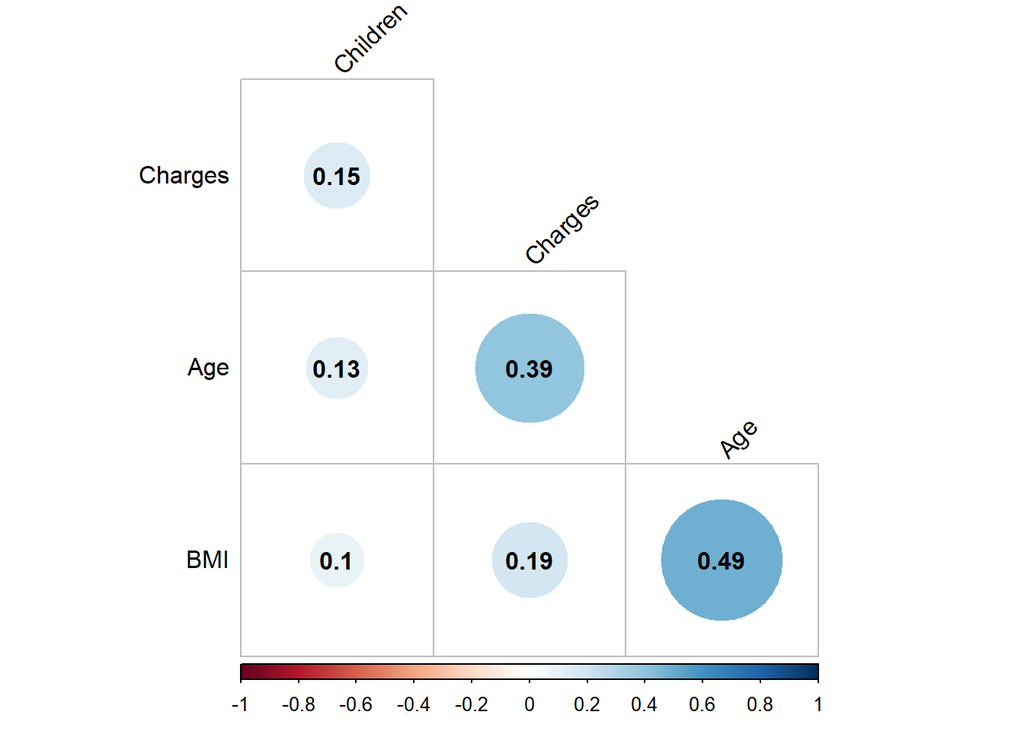

```r
corrplot(cor(insurance),
type = "lower",
order = "hclust",
tl.col = "black",
tl.srt = 45,
addCoef.col = "black",
diag = FALSE)
```

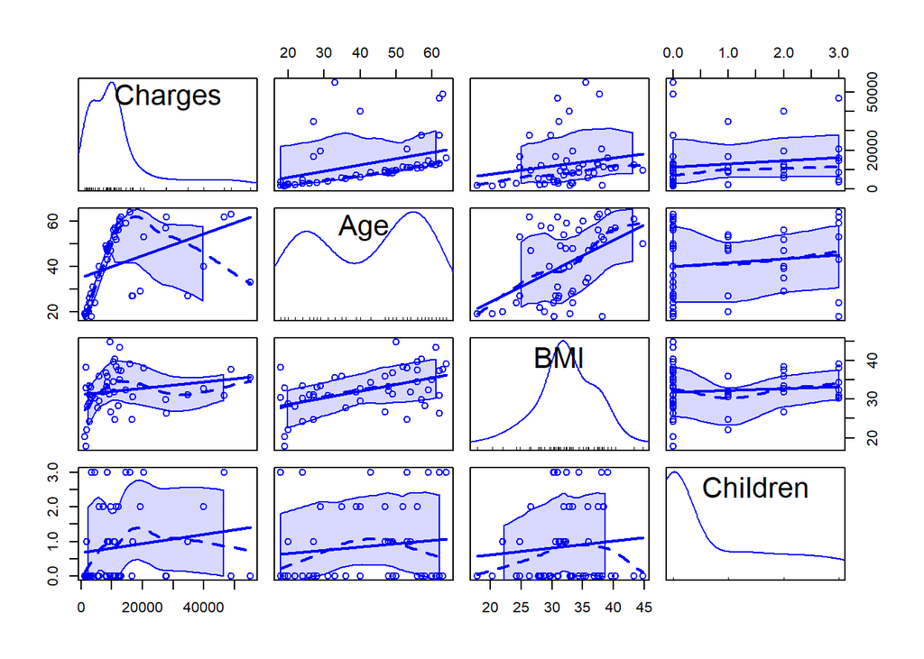

```r
scatterplotMatrix(insurance)
```

# Question 3

Generate a regression equation in the following form:

$$Charges =
\beta_{0}+\beta_{1}*Age+\beta_{2}*BMI+\beta_{3}*Children$$

```r
model <-lm(Charges ~ Age + BMI + Children, data = insurance)
summary (model)
```

```
##
## Call:
## lm(formula = Charges ~ Age + BMI + Children, data = insurance)
##
## Residuals:
##    Min     1Q Median     3Q    Max
##  -7214  -5961  -4847  -2882  45919
##
## Coefficients:
##             Estimate Std. Error t value Pr(>|t|)
## (Intercept)  -454.62   10056.87  -0.045   0.9641
## Age           315.02     126.15   2.497   0.0162 *
## BMI           -20.39     351.17  -0.058   0.9539
## Children     1115.35    1529.01   0.729   0.4694
## ---
## Signif. codes:  0 '***' 0.001 '**' 0.01 '*' 0.05 '.' 0.1 ' ' 1
##
## Residual standard error: 11930 on 46 degrees of freedom
## Multiple R-squared:  0.1656, Adjusted R-squared:  0.1112
## F-statistic: 3.043 on 3 and 46 DF,  p-value: 0.03815
```

```r
summ(model)
```

```
## MODEL INFO:
## Observations: 50
## Dependent Variable: Charges
## Type: OLS linear regression
##
## MODEL FIT:
## F(3,46) = 3.04, p = 0.04
## R² = 0.17
## Adj. R² = 0.11
##
## Standard errors: OLS
## ------------------------------------------------------
##                        Est.       S.E.   t val.      p
## ----------------- --------- ---------- -------- ------
## (Intercept)         -454.62   10056.87    -0.05   0.96
## Age                  315.02     126.15     2.50   0.02
## BMI                  -20.39     351.17    -0.06   0.95
## Children            1115.35    1529.01     0.73   0.47
## ------------------------------------------------------
```

# Question 4

```r
newPrediction <- data.frame(Age = 40,
BMI = 30,
Children = 1)
predict(model, newdata = newPrediction)
```

```
##        1
## 12649.98
```

```r
model$coefficients["Age"]
```

```
##      Age
## 315.0247
```